# Project_Bank_Churn_Prediction_NN

**Evaluation on test**

```python
score2 = Model2.evaluate(X_test,y_test)
```

- The model achieves an accuracy of 86% in test
- Based on accuracy alone we cannot say that the model performs well
- We need to look at other measures like recall, precision etc
- Lets see the confusion matrix, ROC-AUC curve and precision-recall curve to see how well this model performs

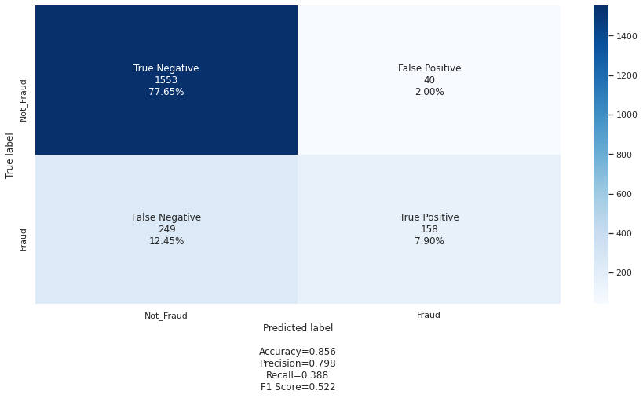

```python
## Confusion Matrix on test set
import seaborn as sn
y_pred1 = Model2.predict(X_test)
for i in range(len(y_test)):
    if y_pred1[i] > 0.5:
        y_pred1[i]=1
    else:
        y_pred1[i]=0



cm2=confusion_matrix(y_test, y_pred1)
labels = ['True Negative','False Positive','False Negative','True Positive']
categories = [ 'Not_Fraud','Fraud']
make_confusion_matrix(cm2,
                      group_names=labels,
                      categories=categories,
                      cmap='Blues')
```

- Recall has dropped a bit, compared to Model-1
- Lets find the optimal threshold and try confusion matrix again with the optimal threshold

```python
#Storing Accuracy,Precision,Recall and F1-score for Model-1 in a dataframe for compare at the end
tn = cm2[0][0]
fp = cm2[0][1]
fn = cm2[1][0]
tp = cm2[1][1]

acc1 = (tp + tn) / (tp + tn + fp + fn)
precision1 = tp/(tp+fp)
recall1 = tp/(tp+fn)
f1 = 2*precision1*recall1/(precision1+recall1)

df = pd.DataFrame(np.array([[acc1,precision1,recall1,f1]]),columns=['Accuracy', 'Precision', 'Recall','F1-Score'],index=['Model2-def'])
df_compare = df_compare.append(df)
```

```
Best Threshold=0.256773, G-Mean=0.748
No Skill: ROC AUC=0.500
Model: ROC AUC=0.829
```

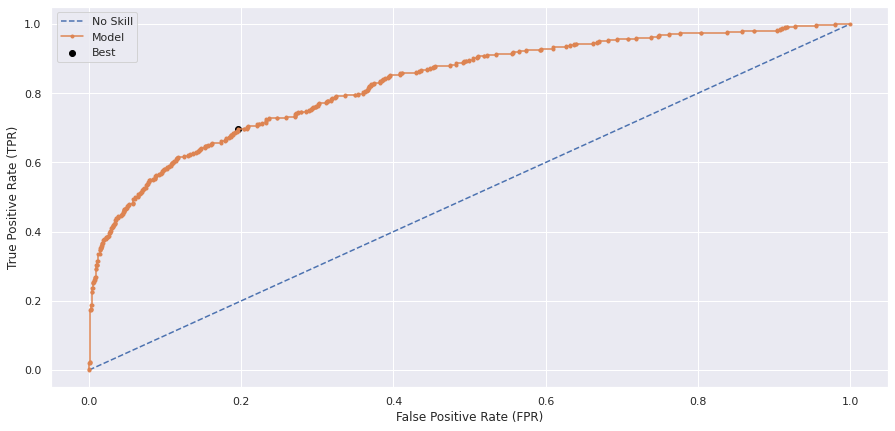

```python
#ROC-AUC curve
fn_ROC_AUC(Model2,X_test,y_test)
```

- AUC different from Model-1

```
Best Threshold=0.321498, F-Score=0.595
```

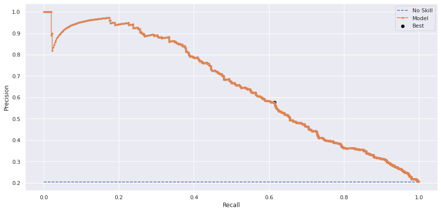

```python
#Precision_Recall
fn_Precision_Recall(Model2,X_test,y_test)
```

- F1-score different from Model-1

```python
#print optimal threshold from precision-recall curve
print('Opimal Threshold = %f' % (best_threshold))
```

```
Opimal Threshold = 0.321498
```

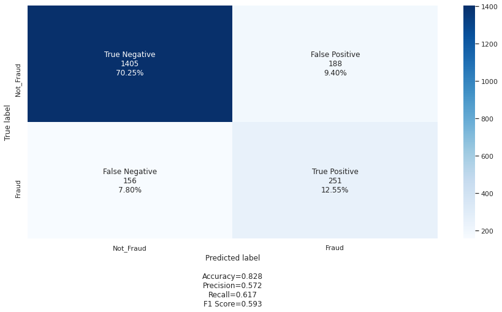

```python
#Confusion matrix based on threshold from Precision_Recall
## Confusion Matrix on test set
import seaborn as sn
y_pred1 = Model2.predict(X_test)
for i in range(len(y_test)):
    if y_pred1[i] > round(best_threshold,2):
        y_pred1[i]=1
    else:
        y_pred1[i]=0



cm2=confusion_matrix(y_test, y_pred1)
labels = ['True Negative','False Positive','False Negative','True Positive']
categories = [ 'Not_Fraud','Fraud']
make_confusion_matrix(cm2,
                      group_names=labels,
                      categories=categories,
                      cmap='Blues')
```

- Recall show slight improvement compared to Model-1 using optimal threshold

```python
#Storing Accuracy,Precision,Recall and F1-score for Model-1 in a dataframe for compare at the end
tn = cm2[0][0]
fp = cm2[0][1]
fn = cm2[1][0]
tp = cm2[1][1]

acc1 = (tp + tn) / (tp + tn + fp + fn)
precision1 = tp/(tp+fp)
recall1 = tp/(tp+fn)
f1 = 2*precision1*recall1/(precision1+recall1)

df = pd.DataFrame(np.array([[acc1,precision1,recall1,f1]]),columns=['Accuracy', 'Precision', 'Recall','F1-Score'],index=['Model2-opt'])
df_compare = df_compare.append(df)
```

**Model-3**

- Using class weight concept, since this is imbalanced dataset

```python
class_weights = class_weight.compute_class_weight('balanced', np.unique(y_train), np.array([y_train.iloc[i] for i in range(len(y_train))]))
class_weights = dict(enumerate(class_weights))
class_weights
```

```
{0: 0.6279434850863422, 1: 2.4539877300613497}
```

- The class 'Exited = 1 is assigned a weight of 2.45 vs 0.62 for the class 'Exited = 0' due to the imbalance between the two classes
- This allows the model to give more importance to the minority class, which is Exited = 1 (customers who left the bank services)

```python
#initialize the model
Model3 = Sequential()

#Initializing the weights uisng he_normal
n_inputs=X_train.shape[1]

Model3.add(Dense(65, input_shape=(n_inputs, ), kernel_initializer='he_normal', activation='relu'))
Model3.add(Dropout(0.5))
Model3.add(Dense(65, kernel_initializer='he_normal', activation='relu'))
Model3.add(Dropout(0.5))
Model3.add(Dense(1, kernel_initializer='he_normal', activation='sigmoid'))

Model3.compile(Adam(lr=0.001), loss='binary_crossentropy', metrics=['accuracy'])
```

```python
Model3.summary()
```

```
Model: "sequential_2"
_________________________________________________________________
Layer (type)                 Output Shape              Param #
=================================================================
dense_7 (Dense)              (None, 65)                780
_________________________________________________________________
dropout_3 (Dropout)          (None, 65)                0
_________________________________________________________________
dense_8 (Dense)              (None, 65)                4290
_________________________________________________________________
dropout_4 (Dropout)          (None, 65)                0
_________________________________________________________________
dense_9 (Dense)              (None, 1)                 66
=================================================================
Total params: 5,136
Trainable params: 5,136
Non-trainable params: 0
_________________________________________________________________
```

```python
#train the model
his_mod3= Model3.fit(X_train, y_train, validation_split=0.2, batch_size=50, epochs=40, class_weight=class_weights, shuffle=True, verbose=1)
```

[output not shown]

- Plotting train and validation loss

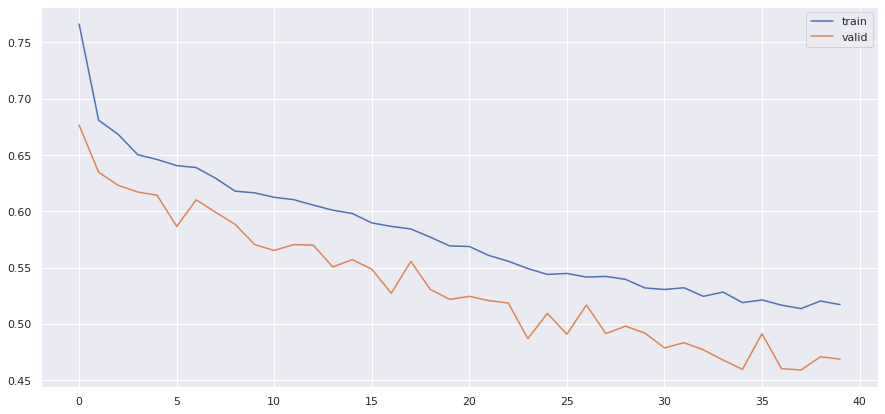

```python
# Capturing learning history per epoch
hist  = pd.DataFrame(his_mod3.history)
hist['epoch'] = his_mod3.epoch

# Plotting accuracy at different epochs
plt.plot(hist['loss'])
plt.plot(hist['val_loss'])
plt.legend(("train" , "valid") , loc =0);
```

- Both training and validation loss show continuous decrease, but with fluctuation

**Evaluation on test**

```python
score3 = Model3.evaluate(X_test,y_test)
```

- The model achieves an accuracy of 78%
- Based on accuracy alone we cannot say that the model performs well
- We need to look at other measures like recall, precision etc
- Lets see the confusion matrix, ROC-AUC curve and precision-recall curve to see how well this model performs

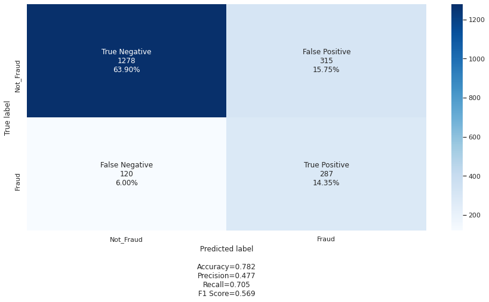

```python
## Confusion Matrix on test set
import seaborn as sn
y_pred1 = Model3.predict(X_test)
for i in range(len(y_test)):
    if y_pred1[i] > 0.5:
        y_pred1[i]=1
    else:
        y_pred1[i]=0



cm2=confusion_matrix(y_test, y_pred1)
labels = ['True Negative','False Positive','False Negative','True Positive']
categories = [ 'Not_Fraud','Fraud']
make_confusion_matrix(cm2,
                      group_names=labels,
                      categories=categories,
                      cmap='Blues')
```

```python
#Storing Accuracy,Precision,Recall and F1-score for Model-1 in a dataframe for compare at the end
tn = cm2[0][0]
fp = cm2[0][1]
fn = cm2[1][0]
tp = cm2[1][1]

acc1 = (tp + tn) / (tp + tn + fp + fn)
precision1 = tp/(tp+fp)
recall1 = tp/(tp+fn)
f1 = 2*precision1*recall1/(precision1+recall1)

df = pd.DataFrame(np.array([[acc1,precision1,recall1,f1]]),columns=['Accuracy', 'Precision', 'Recall','F1-Score'],index=['Model3-def'])
df_compare = df_compare.append(df)
```

```
Best Threshold=0.555411, G-Mean=0.755
No Skill: ROC AUC=0.500
Model: ROC AUC=0.832
```

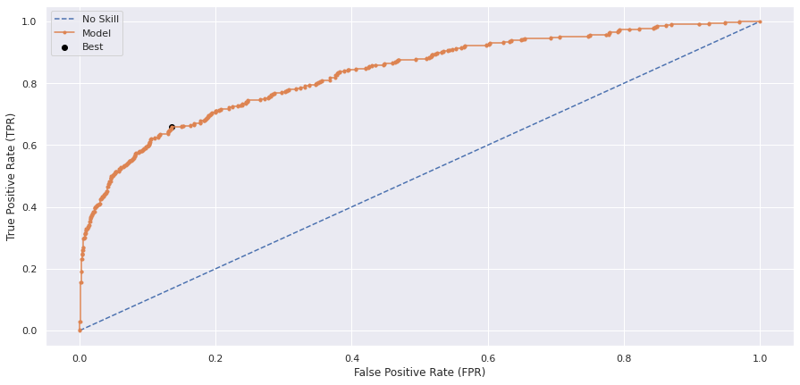

```python
#ROC-AUC curve
fn_ROC_AUC(Model3,X_test,y_test)
```

- AUC improved from Model-2

```
Best Threshold=0.586919, F-Score=0.612
```

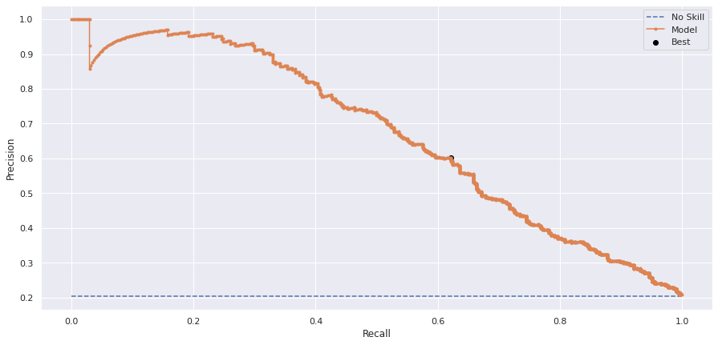

```python
#Precision_Recall
fn_Precision_Recall(Model3,X_test,y_test)
```

- F1-score improved from Model-2

```python
#print optimal threshold from precision-recall curve
print('Opimal Threshold = %f' % (best_threshold))
```

```
Opimal Threshold = 0.586919
```

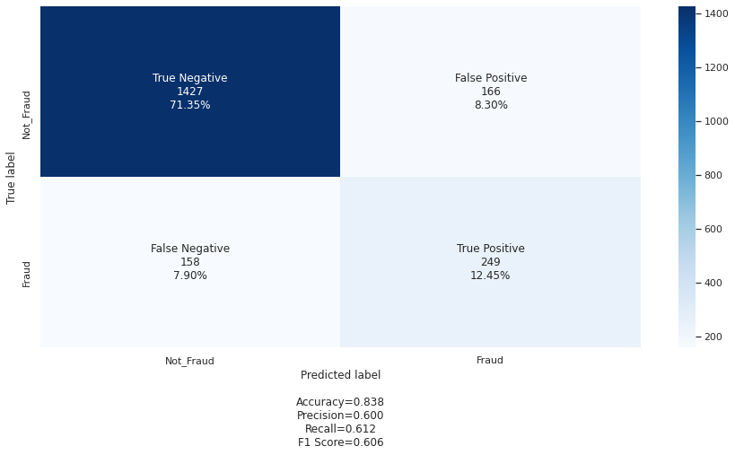

```python
#Confusion matrix based on threshold from Precision_Recall
## Confusion Matrix on test set
import seaborn as sn
y_pred1 = Model3.predict(X_test)
for i in range(len(y_test)):
    if y_pred1[i] > round(best_threshold,2):
        y_pred1[i]=1
    else:
        y_pred1[i]=0



cm2=confusion_matrix(y_test, y_pred1)
labels = ['True Negative','False Positive','False Negative','True Positive']
categories = [ 'Not_Fraud','Fraud']
make_confusion_matrix(cm2,
                      group_names=labels,
                      categories=categories,
                      cmap='Blues')
```

- Recall score is almost the same compared to Model-2 with optimal threshold

```python
#Storing Accuracy,Precision,Recall and F1-score for Model-1 in a dataframe for compare at the end
tn = cm2[0][0]
fp = cm2[0][1]
fn = cm2[1][0]
tp = cm2[1][1]

acc1 = (tp + tn) / (tp + tn + fp + fn)
precision1 = tp/(tp+fp)
recall1 = tp/(tp+fn)
f1 = 2*precision1*recall1/(precision1+recall1)

df = pd.DataFrame(np.array([[acc1,precision1,recall1,f1]]),columns=['Accuracy', 'Precision', 'Recall','F1-Score'],index=['Model3-opt'])
df_compare = df_compare.append(df)
```

**Model-4**

- Resampling the data to oversample the minority class and then build a model on the resampled data
- Oversampling train data using SMOTE

```python
print("Before UpSampling, counts of label 'Existing': {}".format(sum(y_train==0)))
print("Before UpSampling, counts of label 'Attrited': {} \n".format(sum(y_train==1)))

sm = SMOTE(sampling_strategy = 1 ,k_neighbors = 5, random_state=1)   #Synthetic Minority Over Sampling Technique
X_train_over, y_train_over = sm.fit_resample(X_train, y_train)


print("After UpSampling, counts of label 'Existing': {}".format(sum(y_train_over==0)))
print("After UpSampling, counts of label 'Attrited': {} \n".format(sum(y_train_over==1)))


print('After UpSampling, the shape of train_X: {}'.format(X_train_over.shape))
print('After UpSampling, the shape of train_y: {} \n'.format(y_train_over.shape))
```

```
Before UpSampling, counts of label 'Existing': 6370
Before UpSampling, counts of label 'Attrited': 1630

After UpSampling, counts of label 'Existing': 6370
After UpSampling, counts of label 'Attrited': 6370

After UpSampling, the shape of train_X: (12740, 11)
After UpSampling, the shape of train_y: (12740,)
```

- Model-1 on over-sampled data

```python
#fitting the model
his_mod4 = model.fit(X_train_over,y_train_over,batch_size=100,epochs=20,validation_split=0.2)
```

```python
#Evaluation on test
score4 = model.evaluate(X_test,y_test)
```

```
Best Threshold=0.425626, G-Mean=0.764
No Skill: ROC AUC=0.500
Model: ROC AUC=0.846
```

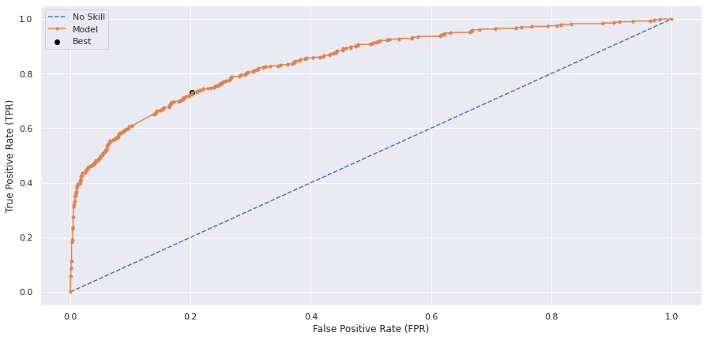

```python
#ROC-AUC curve
fn_ROC_AUC(model,X_test,y_test)
```

```
Best Threshold=0.568296, F-Score=0.613
```

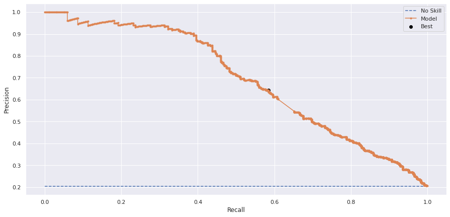

```python
#Precision_Recall
fn_Precision_Recall(model,X_test,y_test)
```

```python
#print optimal threshold from precision-recall curve
print('Opimal Threshold = %f' % (best_threshold))
```

```
Opimal Threshold = 0.568296
```

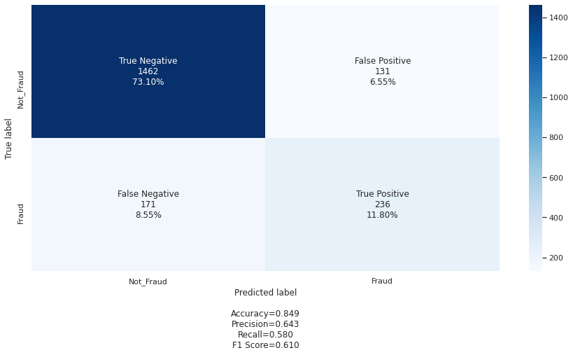

```python
## Confusion Matrix on test set
import seaborn as sn
y_pred1 = model.predict(X_test)
for i in range(len(y_test)):
    if y_pred1[i] > round(best_threshold,2):
        y_pred1[i]=1
    else:
        y_pred1[i]=0



cm2=confusion_matrix(y_test, y_pred1)
labels = ['True Negative','False Positive','False Negative','True Positive']
categories = [ 'Not_Fraud','Fraud']
make_confusion_matrix(cm2,
                      group_names=labels,
                      categories=categories,
                      cmap='Blues')
```

```python
#Storing Accuracy,Precision,Recall and F1-score for Model-1 in a dataframe for compare at the end
tn = cm2[0][0]
fp = cm2[0][1]
fn = cm2[1][0]
tp = cm2[1][1]

acc1 = (tp + tn) / (tp + tn + fp + fn)
precision1 = tp/(tp+fp)
recall1 = tp/(tp+fn)
f1 = 2*precision1*recall1/(precision1+recall1)

df = pd.DataFrame(np.array([[acc1,precision1,recall1,f1]]),columns=['Accuracy', 'Precision', 'Recall','F1-Score'],index=['Model4'])
df_compare = df_compare.append(df)
```

**Model-5**

- Resampling the data to undersample the majority class and then build a model on the resampled data
- Undersampling train data using RandomUnderSampler

```python
rus = RandomUnderSampler(random_state = 1)
X_train_un, y_train_un = rus.fit_resample(X_train, y_train)

print("Before Under Sampling, counts of label 'Existing': {}".format(sum(y_train==0)))
print("Before Under Sampling, counts of label 'Attrited': {} \n".format(sum(y_train==1)))

print("After Under Sampling, counts of label 'Existing': {}".format(sum(y_train_un==0)))
print("After Under Sampling, counts of label 'Attrited': {} \n".format(sum(y_train_un==1)))

print('After Under Sampling, the shape of train_X: {}'.format(X_train_un.shape))
print('After Under Sampling, the shape of train_y: {} \n'.format(y_train_un.shape))
```

```
Before Under Sampling, counts of label 'Existing': 6370
Before Under Sampling, counts of label 'Attrited': 1630

After Under Sampling, counts of label 'Existing': 1630
After Under Sampling, counts of label 'Attrited': 1630

After Under Sampling, the shape of train_X: (3260, 11)
After Under Sampling, the shape of train_y: (3260,)
```

- Model-1 on undersampled data

```python
#fitting the model
his_mod5 = model.fit(X_train_un,y_train_un,batch_size=100,epochs=20,validation_split=0.2)
```

```python
#Evaluation on test
score5 = model.evaluate(X_test,y_test)
```

```
Best Threshold=0.357775, G-Mean=0.757
No Skill: ROC AUC=0.500
Model: ROC AUC=0.842
```

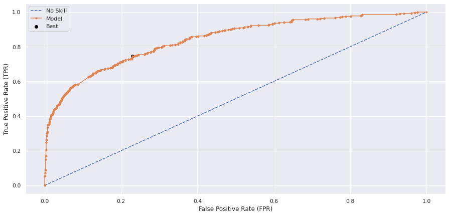

```python
#ROC-AUC curve
fn_ROC_AUC(model,X_test,y_test)
```

```
Best Threshold=0.590970, F-Score=0.618
```

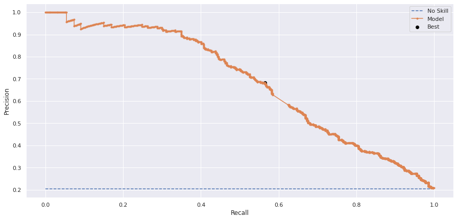

```python
#Precision_Recall
fn_Precision_Recall(model,X_test,y_test)
```

```python
#print optimal threshold from precision-recall curve
print('Opimal Threshold = %f' % (best_threshold))
```

```
Opimal Threshold = 0.590970
```

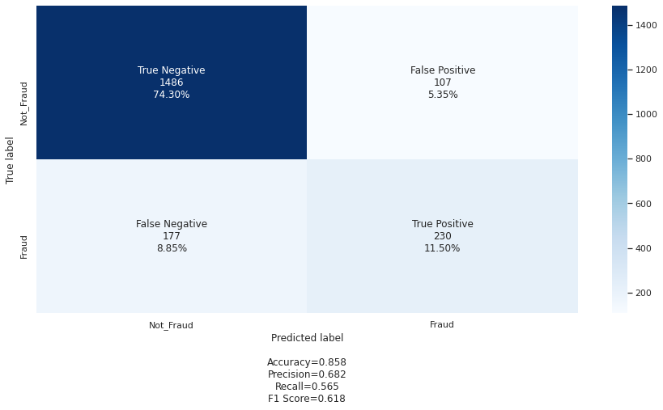

```python
## Confusion Matrix on test set
import seaborn as sn
y_pred1 = model.predict(X_test)
for i in range(len(y_test)):
    if y_pred1[i] > round(best_threshold,2):
        y_pred1[i]=1
    else:
        y_pred1[i]=0



cm2=confusion_matrix(y_test, y_pred1)
labels = ['True Negative','False Positive','False Negative','True Positive']
categories = [ 'Not_Fraud','Fraud']
make_confusion_matrix(cm2,
                      group_names=labels,
                      categories=categories,
                      cmap='Blues')
```

```python
#Storing Accuracy,Precision,Recall and F1-score for Model-1 in a dataframe for compare at the end
tn = cm2[0][0]
fp = cm2[0][1]
fn = cm2[1][0]
tp = cm2[1][1]

acc1 = (tp + tn) / (tp + tn + fp + fn)
precision1 = tp/(tp+fp)
recall1 = tp/(tp+fn)
f1 = 2*precision1*recall1/(precision1+recall1)

df = pd.DataFrame(np.array([[acc1,precision1,recall1,f1]]),columns=['Accuracy', 'Precision', 'Recall','F1-Score'],index=['Model5'])
df_compare = df_compare.append(df)
```

**Model Performance Evaluation**

- Our primary focus for this problem statement is Recall, since we should be looking to reduce false negatives.
- False Negative in this case means this
  - Reality: A customer leaves bank services
  - Model predicted: The customer will NOT leave bank services
- False Negative causes the bank huge loss
- We should also keep an eye on False positives, since that causes the bank to spend more resources
- Here is a dataframe that shows Accuracy, Precision, Recall and F1-score for all models that we created (with **optimal threshold** from Precision-Recall curve)

  ```
  * Random Forest basic model
  * Model1 - Basic DNN
  * Model2 - With early stopping and weight initialization
  * Model3 - With class-weight
  * Model4 - Model-1 on Oversampled data
  * Model5 - Model-1 on Undersampled data
  ```

- Model4 and Model5 are done after resampling since dataset is imbalanced
- For Model 1,2 and 3 we have calculated accuracy,precision and recall based on default threshold (0.5) and optimal threshold from precision-recall curve
- Example -> **Model1-def** is the metrics with threshold 0.5 and **Model1-opt** is the metrics with optimal threshold

```python
#dataframe with Accuracy, Precision, Recall and F1-score for all models that we created
df_compare
```

|  | Accuracy | Precision | Recall | F1-Score |
| --- | --- | --- | --- | --- |
| RandomForest | 0.8690 | 0.773585 | 0.503686 | 0.610119 |
| Model1-def | 0.8655 | 0.859375 | 0.405405 | 0.550918 |
| Model1-opt | 0.8635 | 0.720395 | 0.538084 | 0.616034 |
| Model2-def | 0.8555 | 0.797980 | 0.388206 | 0.522314 |
| Model2-opt | 0.8280 | 0.571754 | 0.616708 | 0.593381 |
| Model3-def | 0.7825 | 0.476744 | 0.705160 | 0.568880 |
| Model3-opt | 0.8380 | 0.600000 | 0.611794 | 0.605839 |
| Model4 | 0.8490 | 0.643052 | 0.579853 | 0.609819 |
| Model5 | 0.8580 | 0.682493 | 0.565111 | 0.618280 |

**Conclusion**

As you can see here when recall is improved, precision drops a bit. We tried the following improvement steps:

1) Found out threshold using ROC-AUC, Precision-Recall

2) Done Early stopping and weight initialization

3) Appied class-weight, since this is imbalanced dataset

4) Oversampling done using SMOTE to add more samples for minority class and match it with majority class

5) Undersampling done to reduce samples for majority class and match it with minority class

There is still scope of improvements as :

1) Hyperparameter tuning can be applied to tune different Hyperparameters like learning rate etc.

**Business Recommendation**

- This model can be used to predict if a customer is going to leave bank services or not, provided the feature set is going to be the same.
- Even though the model gives more focus on false negative predictions (model predicts customer will NOT leave bank services, but customer actually leaves bank services), there is some insight towards false positive predictions (model predicts customer will leave bank services, but customer actually does NOT leave bank services) too, which in turn causes the bank extra resources.
- Based on the analysis done by using different models, these are some of the key features bank can focus on while deciding if a customer is going to leave bank services or not

  ```
  * Geography
  * Gender
  * Number of Products owned by customers
  * IsActiveMember
  * Credit Score
  * Age
  * Balance (Account balance)
  ```

- Bank can see why Exited customer % is higher for Germany
- Bank can see why Exited customer % is higher for Females
- Bank can see why Exited customer % is higher for customers having 3 or 4 products. This could be because the customers are not happy with these product services. Bank can focus on how to improve customer satisfaction in those areas
- Bank can focus in active members, since they tend to keep using bank services
- Customers with lower credit score seem to be leaving bank services more, this could be because bank is offering more services to those who are having high credit scores
- Bank can see why Exited customer % is higher for older customers, bank can think of ways to keep them, like giving them additional benefits or offers
- Bank can provide some benefits or offers to female customers to keep them
- Bank can provide some benefits or offers to customers from Germany to reduce Exit %.